# NetPerturb Report

Perturbation scores across targets and cell types

Published

November 9, 2026

## 1 Overview

This report summarizes 1045 perturbation scores from perbscore_all_targets.txt, covering 55 target(s) across 19 cell type(s), scored under 1 binding mode(s) (antagonist).

The gene regulatory networks these scores were computed from were inferred with **hdWGCNA** (`--network`: hdwgcna). Every score below is relative to that network type, so scores from a run using a different inference method are not directly comparable.

### 1.1 Target QC

Every requested target gene passed QC checking.

## 2 Perturbation score table

Use the column filters below to query by cell type, target, or binding.

| cell_type | target | binding | perb_score |
| --- | --- | --- | --- |
| B | AURKA | antagonist | 3.68831577225561e-06 |
| CTL | AURKA | antagonist | 2.88088202284062e-05 |
| GMP | AURKA | antagonist | 4.22345157792474e-05 |
| GMP-like | AURKA | antagonist | 0.000743651882408564 |
| HSC | AURKA | antagonist | 2.00870574252004e-05 |
| HSC-like | AURKA | antagonist | 2.27065223430535e-05 |
| Mono | AURKA | antagonist | 0.00034910906500886 |
| Mono-like | AURKA | antagonist | 7.39343991485682e-07 |
| NK | AURKA | antagonist | 8.75407789484197e-05 |
| Plasma | AURKA | antagonist | 0.000368694009123038 |

[output cut: 1035 more lines]

## 3 Perturbation score distribution

The left panel is every score, so the cut can be checked against where the two modes actually separate — move it with `--score_quantile` if the red line does not fall in the valley between them. The right panel is what the heatmap below works with, on its own axis.

The green dashed line in both panels is the Top 2.5% threshold (-2.392), the 27 strongest score(s) in the run. Those are the scores the heatmap asterisks mark.

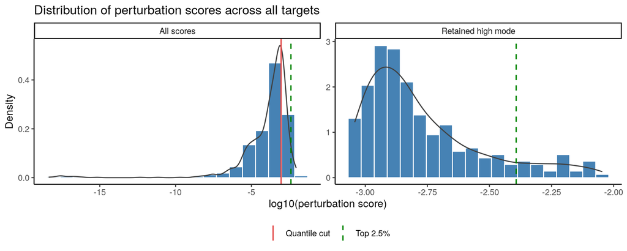

## 4 Perturbation score heatmap

Scores are log10-transformed and cut as above, so the colour scale spans the high mode only. Tiles below the cut, and those whose score is non-positive, are shown as missing (gray). An asterisk marks a score in the Top 2.5% of every score in the run — 27 tile(s), at or above -2.392 on the log10 scale.

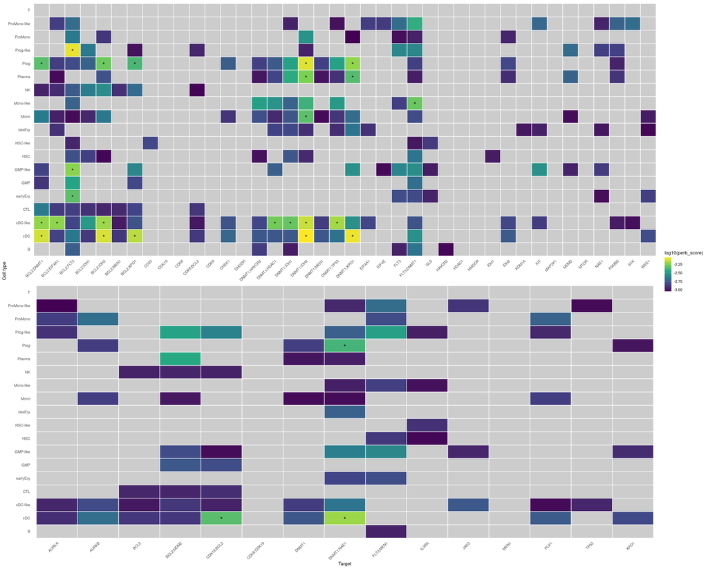

## 5 Knockout networks

Each knockout and the genes it moved. scTenifoldKnk zeroes the target’s outgoing edges, realigns the knocked-out network against the wild-type one, and scores every gene on how far it travelled between the two; the genes drawn here are the ones clearing FDR < 0.05 on p.adj. Use the menu to switch between the 0 target and cell type combinations.

The knocked-out gene sits at the centre and the genes it moved sit around it. A combined target such as `A;B` is a single joint knockout, with both genes’ edges zeroed together, so all of its genes sit at the centre, each linked to every gene the knockout moved. A node’s size follows its log2FC, scaled within the combination on display, so sizes rank genes against each other rather than across cell types. The ring is capped at the 25 strongest genes per combination; the table in the next section is not capped. Hover any node for its exact values.

`log2FC` is the log2 ratio of a gene’s squared alignment distance to the mean squared distance of its run, so it says how far a gene moved and not which way it went. It carries no direction, which is why no edge on this figure has a sign to read off: every gene shown simply moved further than its run’s average.

scTenifoldKnk was not run for this session, so there is no knockout network to draw. Pass `--sctknk` to generate one.

## 6 Knockout differentially-regulated genes

Every gene clearing FDR < 0.05 on p.adj, across all cell type and target combinations and with no cap on how many are listed per combination. `distance` is how far the gene moved between the wild-type and knocked-out networks; `log2FC` is that distance squared over the run’s mean, logged; `p.value` tests it against the chi-square null and `p.adj` is the Benjamini-Hochberg adjustment within the run.

`p.value` is a direct function of `log2FC`, so the two rank genes identically and a cut on `p.adj` is the same thing as a `log2FC` threshold. The knocked-out genes themselves are left out: they always move furthest by construction, so their rows say nothing about the knockout’s effect.

Currently 0 gene(s) clear FDR < 0.05, across 0 target(s) and 0 cell type(s).

scTenifoldKnk was not run for this session, so no differentially-regulated gene table is shown. Pass `--sctknk` to generate one.

### 6.1 Genes affected per knockout

scTenifoldKnk was not run for this session.

## 7 Knockout gene set enrichment

What the knockout moved, read as processes rather than genes. Every gene is ranked by log2FC – the log2 of its squared manifold-alignment distance over the run’s mean squared distance, so the ranking is the one scTenifoldKnk’s own paper feeds to GSEA, centred on the average gene rather than on zero – and each gene set is scored on how concentrated it is at either end of that ranking. Use the menu to switch between the 0 target and cell type combinations.

`NES` is the enrichment score normalised for set size, and it is signed here. Read the sign carefully: the ranking is by how far a gene moved, not by which way it moved, so a **positive** `NES` says a set is crowded into the genes the knockout disturbed most, and a **negative** one says the set sat still while the rest of the network moved. Neither is up- or down-regulation – there is no direction of expression anywhere in the scTenifoldKnk output to recover.

Each dot is one gene set: position on the x-axis is its `NES`, size is how many genes of it sit in the leading edge, and colour is `-log(p.adj + 1)`, running blue at the weak end of the cut through to red at the significant end. That statistic is close to linear near `p.adj` of 0, so it separates the marginal sets from the rest and treats everything below about 0.01 as equally significant; the exact `p.adj` of every set is a column of the table. Sets are drawn only if they clear FDR < 0.25, the 20 strongest per combination by absolute `NES`. Hover any dot for its exact values; the table below carries all of them, uncapped.

One thing to keep in mind reading any of it: the genes ranked here are the ones each knockout network was built on – every gene detected in more than 5% of the cell type’s cells, plus the targets – not the whole transcriptome. Enrichment is relative to that universe, so a pathway carried by rarely detected genes cannot show up here.

No gene set file was supplied, so no enrichment was run. Pass `--gsea_gmt` with a GMT for this run’s species alongside `--sctknk`.

No gene set file was supplied, so no enrichment was run and there is no table to show. Pass `--gsea_gmt` alongside `--sctknk`.

## 8 Cell identity overview

The identities scored above, as they sit in the embedding. This is the cell set after downsampling, so the group sizes are the ones the networks were actually inferred from rather than those of the full object.

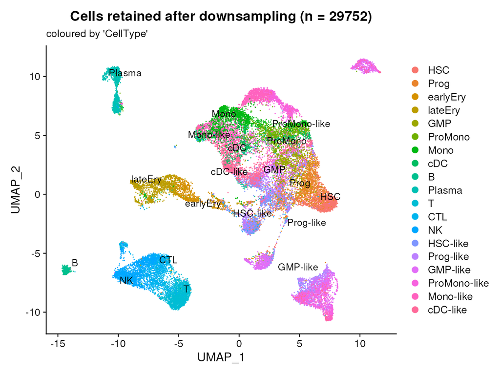

### 8.1 Cells per identity

Cells and genes each identity’s network was built from. **29,752** cells were used in total, across 19 identities (`--n_cells` 2000 per identity, `--min_cells` 500; genes: every rank-score network (GENIE3, scRank, hdWGCNA) is offered the same **3,376** of the object’s 27,807 genes left after removing 92 mitochondrial and ribosomal protein genes on load (`gene4use`: `--n_hvg` 1000 variable genes plus the species’ transcription factors, drug targets and the requested targets), and each identity keeps those with counts in its own cells, **2,272–2,759** genes per network). In the cells panel the grey bar behind each is the identity’s size in the input object; an identity dropped for `--min_cells` has only that bar, in orange. In the genes panel the pale green part is `gene4use` genes with zero counts in that identity, which can have no edges in its network: hdWGCNA pads them with zeros, and GENIE3 and scRank have nothing to fit them on. 2 identities were dropped for having fewer than `--min_cells` cells after downsampling, and no network was built from them.

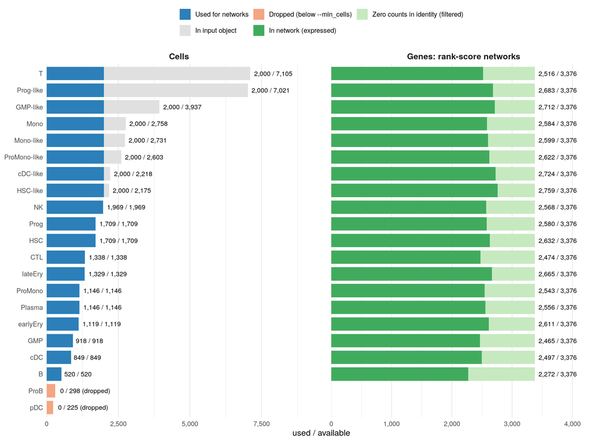

| Identity | Status | Cells in input | Cells used | Genes in object | gene4use | Genes in network | Genes filtered |
| --- | --- | --- | --- | --- | --- | --- | --- |
| B | kept | 520 | 520 | 27807 | 3376 | 2272 | 1104 |
| cDC | kept | 849 | 849 | 27807 | 3376 | 2497 | 879 |
| cDC-like | kept | 2218 | 2000 | 27807 | 3376 | 2724 | 652 |
| CTL | kept | 1338 | 1338 | 27807 | 3376 | 2474 | 902 |
| earlyEry | kept | 1119 | 1119 | 27807 | 3376 | 2611 | 765 |
| GMP | kept | 918 | 918 | 27807 | 3376 | 2465 | 911 |
| GMP-like | kept | 3937 | 2000 | 27807 | 3376 | 2712 | 664 |
| HSC | kept | 1709 | 1709 | 27807 | 3376 | 2632 | 744 |
| HSC-like | kept | 2175 | 2000 | 27807 | 3376 | 2759 | 617 |
| lateEry | kept | 1329 | 1329 | 27807 | 3376 | 2665 | 711 |

[output cut: 11 more lines]

### 8.2 Target expression per identity

Mean expression of each target gene in each identity, over the cells retained after downsampling – the cells its network was built from. A combined target (`A;B`) is shown as its single genes, each on its own. Expression is log-normalised (counts per 10,000, then log1p), and the number under each value is the percentage of the identity’s cells with at least one count of the gene. A target that is barely expressed in an identity has little for that identity’s network to connect it to, which is worth keeping in mind when reading its scores above.

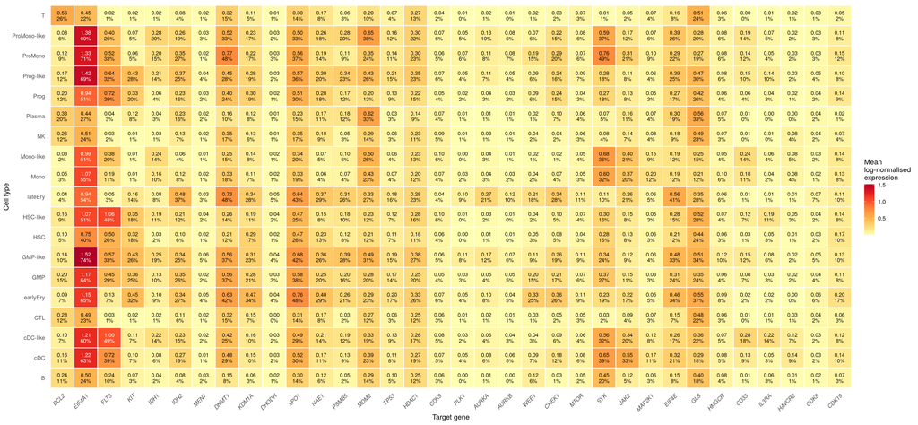

## 9 Data quality

Diagnostics for reading the results above, not filters: each check is a reason an identity’s network, and every score or knockout from it, might be skewed. The thresholds are rules of thumb, and several compare an identity with the others in this run rather than with a fixed value, since what counts as shallow or dense depends on the dataset and the network method.

**509** check(s) flagged, listed below.

| Identity | Area | Check | Value | Flagged at | Why it matters |
| --- | --- | --- | --- | --- | --- |
| HSC | Input | High mito/ribo share | 38% | &gt; run median + 10% | Points at stressed or damaged cells, whose expression reflects that state. |
| B | Input | Sparse matrix | 97% | &gt; 95% | Mostly-zero genes give unstable regressions and correlations. |
| cDC-like | Input | Sparse matrix | 95% | &gt; 95% | Mostly-zero genes give unstable regressions and correlations. |
| CTL | Input | Sparse matrix | 97% | &gt; 95% | Mostly-zero genes give unstable regressions and correlations. |
| HSC | Input | Sparse matrix | 96% | &gt; 95% | Mostly-zero genes give unstable regressions and correlations. |
| HSC-like | Input | Sparse matrix | 96% | &gt; 95% | Mostly-zero genes give unstable regressions and correlations. |
| Mono | Input | Sparse matrix | 95% | &gt; 95% | Mostly-zero genes give unstable regressions and correlations. |
| Mono-like | Input | Sparse matrix | 96% | &gt; 95% | Mostly-zero genes give unstable regressions and correlations. |
| NK | Input | Sparse matrix | 97% | &gt; 95% | Mostly-zero genes give unstable regressions and correlations. |
| Plasma | Input | Sparse matrix | 95% | &gt; 95% | Mostly-zero genes give unstable regressions and correlations. |

[output cut: 499 more lines]

### 9.1 Input quality per identity

Each identity’s retained cells, the ones its networks were built from. **Depth** is the median count per cell and **genes** the median detected; **mito/ribo share** is the median share of a cell’s counts in the mitochondrial and ribosomal genes removed on load. **Sparsity** is the share of zeros in the matrix the rank-score networks are fitted on. **PC1 variance** is the share of that matrix’s variance in its first principal component, and **PC-depth rho** the strongest Spearman correlation between one of its first five components and log depth. Pass `--batch` to add each identity’s batch composition. Red marks a flagged value.

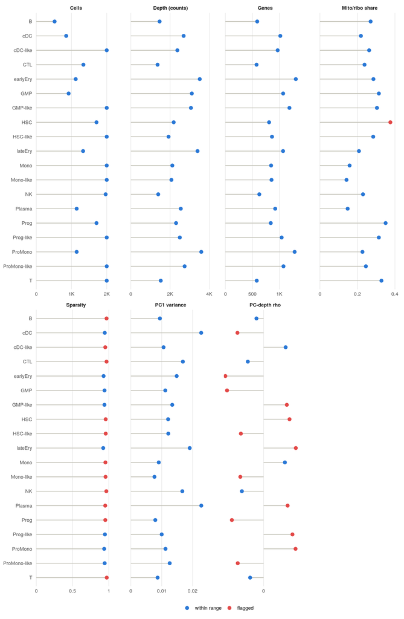

### 9.2 Network structure

Every network the run built, one row per identity. Weights are on different scales for each method, so each cell is coloured by how far it sits from that track’s median across identities, blue below and red above, and labelled with the value itself. **Density** is the share of possible edges present; **mean |weight|** the average edge strength; **isolated** the share of genes with no edges; **top 1% hub share** how much of the network’s total strength its top 1% of genes hold, and **strength Gini** how unequal strength is across genes. An identity whose network is much denser or stronger than the others can have every target’s score shifted with it. For hdWGCNA, **metacells** is how many metacells the correlations were taken over, and **scale-free R2** the fit at the soft power used.

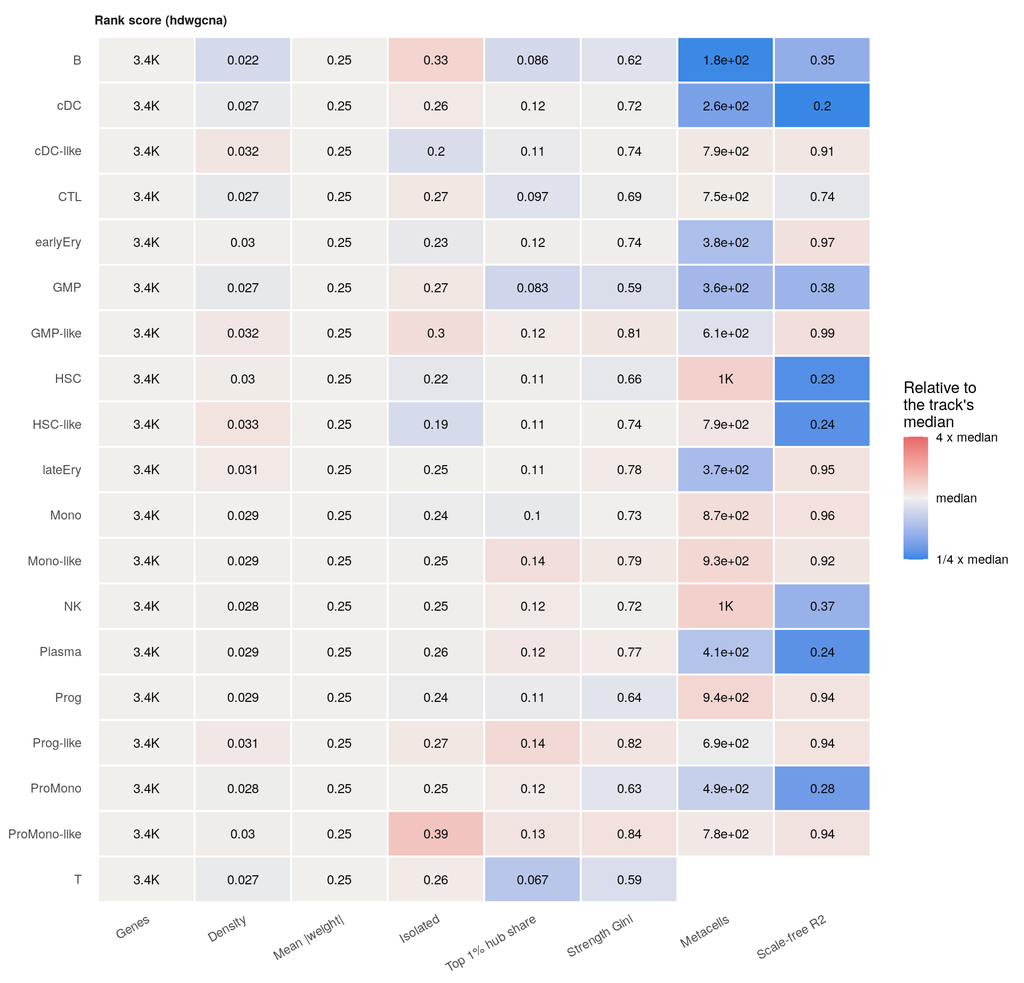

### 9.3 Targets in their networks

Where each target gene sits in each identity’s rank-score network: the share of the network’s genes with less total edge strength than it, so 0 is an isolated gene and 100 the strongest hub. Unlike raw strength, this is comparable across identities. The second line is the target’s standardised variance (vst) in that identity: around 1 is what sampling noise alone gives, so a target near 1 has no structure for a network to connect it to, however well it is detected. A score for a target in the bottom percentiles, or at noise level, mostly reflects the rest of the network.

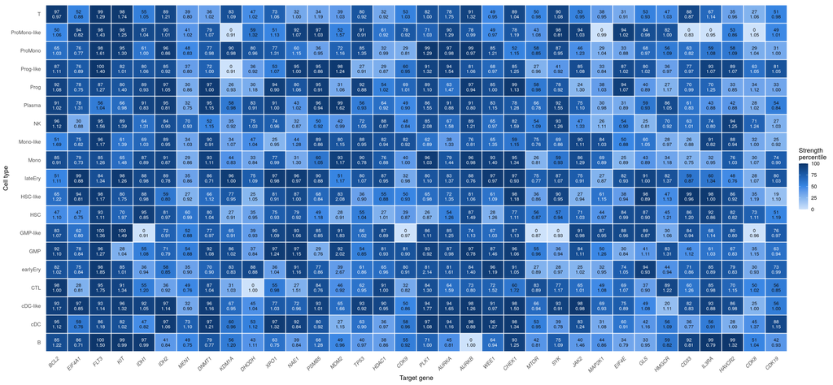

| identity | n_cells | median_counts | median_genes | median_mt_rb_frac | sparsity_gene4use | pc1_var_frac | top5_var_frac | pc1_depth_rho | max_pc_depth_rho | max_pc_depth | n_batches | largest_batch_frac | batch_entropy | batch_r2 |
| --- | --- | --- | --- | --- | --- | --- | --- | --- | --- | --- | --- | --- | --- | --- |
| B | 520 | 1470 | 590 | 0.27 | 0.969 | 0.00942 | 0.0358 | -0.16 | -0.16 | 1 |  |  |  |  |
| cDC | 849 | 2690 | 1020 | 0.219 | 0.944 | 0.0228 | 0.0561 | 0.31 | -0.586 | 2 |  |  |  |  |
| cDC-like | 2000 | 2370 | 968 | 0.262 | 0.951 | 0.0106 | 0.0292 | 0.493 | 0.493 | 1 |  |  |  |  |
| CTL | 1338 | 1360 | 577 | 0.238 | 0.969 | 0.0168 | 0.0494 | -0.116 | -0.354 | 3 |  |  |  |  |
| earlyEry | 1119 | 3510 | 1300 | 0.285 | 0.928 | 0.0148 | 0.0413 | -0.857 | -0.857 | 1 |  |  |  |  |
| GMP | 918 | 3110 | 1070 | 0.314 | 0.941 | 0.0112 | 0.0303 | -0.819 | -0.819 | 1 |  |  |  |  |
| GMP-like | 2000 | 3060 | 1190 | 0.304 | 0.94 | 0.0134 | 0.0366 | 0.422 | 0.52 | 3 |  |  |  |  |
| HSC | 1709 | 2180 | 809 | 0.376 | 0.957 | 0.0121 | 0.0345 | 0.0841 | 0.581 | 5 |  |  |  |  |
| HSC-like | 2000 | 1920 | 863 | 0.284 | 0.957 | 0.0121 | 0.0347 | -0.263 | -0.509 | 2 |  |  |  |  |
| lateEry | 1329 | 3400 | 1070 | 0.208 | 0.923 | 0.0191 | 0.0522 | 0.722 | 0.722 | 1 |  |  |  |  |

[output cut: 9 more lines]

| track | method | identity | n_genes | n_edges | density | mean_abs_weight | isolated_frac | hub_share_top1pct | strength_gini | n_metacells | soft_power | power_estimate | sft_r2 | metacells_per_gene |
| --- | --- | --- | --- | --- | --- | --- | --- | --- | --- | --- | --- | --- | --- | --- |
| rank_score | hdwgcna | B | 3376 | 255268 | 0.0224 | 0.25 | 0.331 | 0.0856 | 0.619 | 182 | 6 |  | 0.354 | 0.0539 |
| rank_score | hdwgcna | cDC | 3376 | 308390 | 0.0271 | 0.25 | 0.264 | 0.115 | 0.717 | 258 | 6 |  | 0.199 | 0.0764 |
| rank_score | hdwgcna | ProMono | 3376 | 321692 | 0.0282 | 0.25 | 0.249 | 0.12 | 0.632 | 488 | 6 |  | 0.276 | 0.145 |
| rank_score | hdwgcna | lateEry | 3376 | 351524 | 0.0309 | 0.25 | 0.247 | 0.113 | 0.779 | 372 | 6 |  | 0.951 | 0.11 |
| rank_score | hdwgcna | Prog-like | 3376 | 356312 | 0.0313 | 0.25 | 0.268 | 0.143 | 0.823 | 691 | 6 |  | 0.937 | 0.205 |
| rank_score | hdwgcna | ProMono-like | 3376 | 341782 | 0.03 | 0.25 | 0.389 | 0.128 | 0.841 | 776 | 6 |  | 0.941 | 0.23 |
| rank_score | hdwgcna | HSC-like | 3376 | 376066 | 0.033 | 0.25 | 0.193 | 0.113 | 0.74 | 790 | 6 |  | 0.238 | 0.234 |
| rank_score | hdwgcna | Mono | 3376 | 331660 | 0.0291 | 0.25 | 0.237 | 0.104 | 0.73 | 872 | 6 |  | 0.96 | 0.258 |
| rank_score | hdwgcna | HSC | 3376 | 345188 | 0.0303 | 0.25 | 0.222 | 0.111 | 0.663 | 1000 | 6 |  | 0.231 | 0.296 |
| rank_score | hdwgcna | GMP | 3376 | 302704 | 0.0266 | 0.25 | 0.271 | 0.083 | 0.589 | 355 | 6 |  | 0.384 | 0.105 |

[output cut: 9 more lines]

## 10 Pipeline run

This run (**romantic_davinci**) started on **2026-11-09 14:41:17 -0300** and reached this report **42m 08s** later, on 2026-11-09 15:23:24 -0300. That is the whole run except rendering the report itself; Nextflow’s own execution report in `pipeline_info/` has the final total. The run was resumed, so 0 task(s) were restored from cache and their times below are those of the run that first produced them.

Command line:

```bash
nextflow run /mnt/beegfs/scratch/lgdqamorim/projeto_nextflow/nf_scrank/main.nf -profile singularity,test_vangalen --outdir /mnt/beegfs/scratch/lgdqamorim/projeto_nextflow/nf_scrank/results_hdwgcna --n_cores 32 --network hdwgcna --max_cpus 64 --max_memory 64.GB --max_time 12h --min_cells 500 -resume --n_cells 2000 --n_hvg 1000 --target /mnt/beegfs/scratch/lgdqamorim/projeto_nextflow/nf_scrank/testdata/test_input_vangalen_expanded.txt -w /mnt/beegfs/scratch/lgdqamorim/projeto_nextflow/nf_scrank/work_bench/vangalen_hdwgcna
```

| Field | Value |
| --- | --- |
| Run name | romantic_davinci |
| Session ID | 379a61ce-ccde-4c20-8c84-cfa3059e772d |
| Started | 2026-11-09 14:41:17 -0300 |
| Profile | singularity,test_vangalen |
| Container engine | singularity |
| Nextflow version | 25.10.3 |
| Pipeline version | 0.1.0dev |
| Revision | local |
| User | lgdqamorim |
| Launch directory | /mnt/beegfs/scratch/lgdqamorim/projeto_nextflow/nf_scrank/nf_home/vangalen_hdwgcna |

[output cut: 18 more lines]

### 10.1 Running time per step

Every task of the run bar the report, from Nextflow’s execution trace. A step that fans out – one task per cell type, or per cell type and target – is averaged over its tasks; the time is each task’s own run time (`realtime`), not counting time spent queued. Summed over every task that is **4h 57m** of compute, against **42m 08s** of wall-clock time.

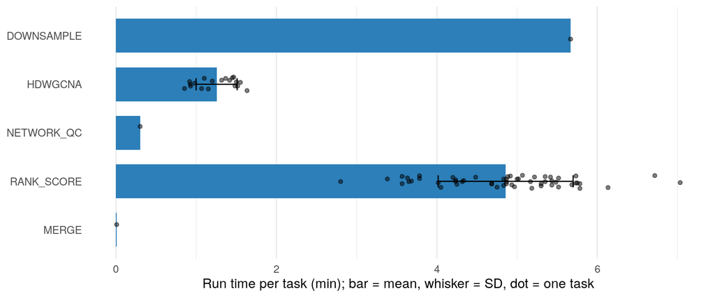

| Step | Tasks | Cached | Failed | Mean | SD | Min | Max | Total |
| --- | --- | --- | --- | --- | --- | --- | --- | --- |
| DOWNSAMPLE | 1 | 0 | 0 | 5m 40s | - | 5m 40s | 5m 40s | 5m 40s |
| HDWGCNA | 19 | 0 | 0 | 1m 15s | 15.3 s | 51.2 s | 1m 38s | 23m 49s |
| NETWORK_QC | 1 | 0 | 0 | 18.0 s | - | 18.0 s | 18.0 s | 18.0 s |
| RANK_SCORE | 55 | 0 | 0 | 4m 51s | 50.5 s | 2m 48s | 7m 02s | 4h 27m |
| MERGE | 1 | 0 | 0 | 0.5 s | - | 0.5 s | 0.5 s | 0.5 s |